# Weight Lifting Exercise Dataset: How well are exercised performed?

Gordon CHAN

2015/9/16

# Introduction

In this assignment we perform analysis on the *Weight Lifting Exercises Dataset* by Velloso et al. The aim of the study focus on how well are people performing exercise. In which 6 participants performed barbell lifts correctly and incorrectly in 5 different ways, with accelerometers on the belt, forearm, arm and dumbell on these participants.

In this assignment, I will try to build a model which can predict how well the participants are performing the exercise.

# R-packages and Dataset

The training and testing datasets are downloaded. For the analysis the *Caret* package is used. Since the training datasets is large (11.6MB) the *doParallel* package is also used to enable multi-core processing in R to enhance the data processing speed.

```r
library(caret)
# enable multi-core processing
library(doParallel)
registerDoParallel(makeCluster(detectCores(), outfile=""))
```

```r
# Reading the datasets
training <- read.csv(file.path("datasets", "pml-training.csv"), header = TRUE, sep = ",", na.strings=c("","NA", "#DIV/0!"))
testing <- read.csv(file.path("datasets", "pml-testing.csv"), header = TRUE, sep = ",", na.strings=c("","NA", "#DIV/0!"))

# Filesize of training dataset in Megabyte
file.size(file.path("datasets", "pml-training.csv"))/2^20
```

```
## [1] 11.63744
```

# Exploratory Data Analysis

Two datasets are provided, each containing 160 variables, the testing set contains 20 observations while the training set contains 19622 observations.

```r
# Dimensions of the datasets
dim.data.frame(testing)
```

```
## [1]  20 160
```

```r
dim.data.frame(training)
```

```
## [1] 19622   160
```

If we take a look at the first and last 10 variables of the dataset, we could see that the first 7 variables contained data regarding the subjects and data collection, while from 8th variable onwards until the second last variable contained measurements from the sensors. For our model fitting, only these variables are useful as predictors.

```r
# First 10 variables
names(training)[1:10]
```

```
##  [1] "X"                    "user_name"            "raw_timestamp_part_1"
##  [4] "raw_timestamp_part_2" "cvtd_timestamp"       "new_window"
##  [7] "num_window"           "roll_belt"            "pitch_belt"
## [10] "yaw_belt"
```

```r
# Last 10 variables
names(training)[151:160]
```

```
##  [1] "gyros_forearm_x"  "gyros_forearm_y"  "gyros_forearm_z"
##  [4] "accel_forearm_x"  "accel_forearm_y"  "accel_forearm_z"
##  [7] "magnet_forearm_x" "magnet_forearm_y" "magnet_forearm_z"
## [10] "classe"
```

| Class | Description |
| --- | --- |
| A | According to the specification (The correct way) |
| B | Throwing the elbows to the front |
| C | Lifting the dumbbell only halfway |
| D | Lowering the dumbbell only halfway |
| E | Throwing the hips to the front |

```r
# Summary of the outcome variaible
summary(training$classe)
```

```
##    A    B    C    D    E
## 5580 3797 3422 3216 3607
```

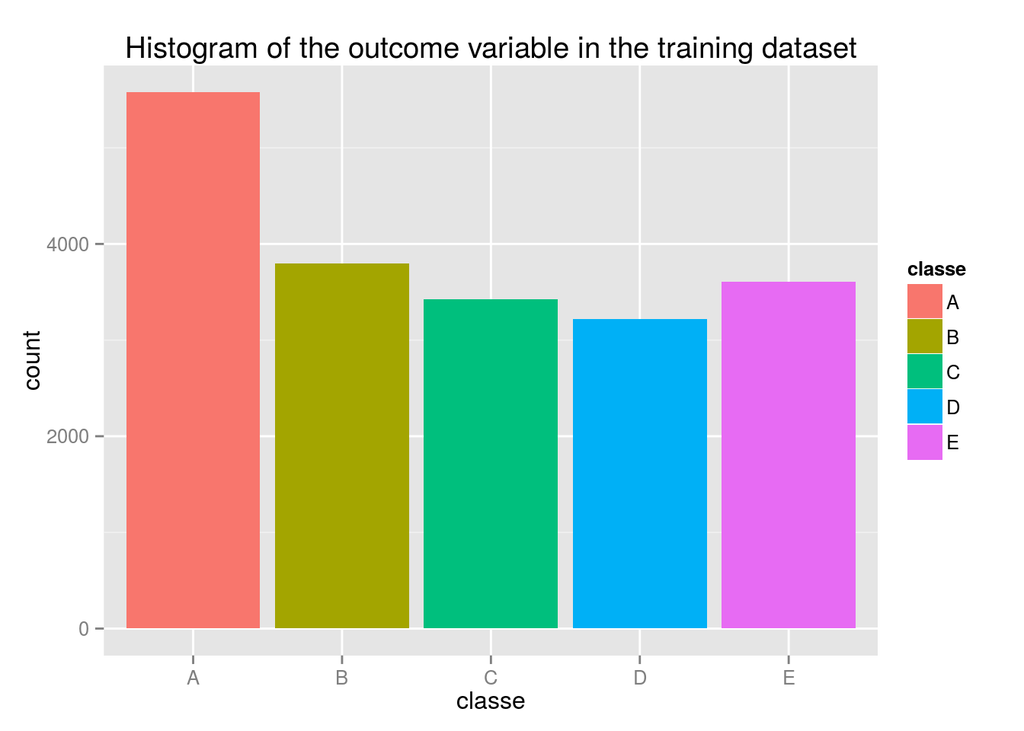

```r
# Histogram of the outcome variable in training dataset
qplot(x = classe, fill = classe, data = training, main = "Histogram of the outcome variable in the training dataset")
```

Before we proceed further, the missing values for each of the variables in the datasets are checked. We can see that there are only 60 variables which have no missing values, while 100 variables contained a majority of missing values out of 19622 observations. As a major portion of the data is unavailable there is no meaningful way of inferring them, hence these variables are of little value to our model fitting.

```r
# Number of variables vs Number of NA in each variable
table(colSums(is.na(training)))
```

```
##
##     0 19216 19217 19218 19220 19221 19225 19226 19227 19248 19293 19294
##    60    67     1     1     1     4     1     4     2     2     1     1
## 19296 19299 19300 19301 19622
##     2     1     4     2     6
```

# Data Pre-Processing

The datasets are subseted by removing unnecessary variables. Identical variables removed are removed from the training and testing sets.

```r
# Remove the first 7 variables from the datasets
rm_col <- names(training)[1:7]
training <- subset(training, select=!(names(training) %in% rm_col))
testing <- subset(testing, select=!(names(testing) %in% rm_col))

# Remvoe variables with majority number of NA
rm_col_na <- names(which(colSums(is.na(training)) != 0))
training <- subset(training, select=!(names(training) %in% rm_col_na))
testing <- subset(testing, select=!(names(testing) %in% rm_col_na))
```

# Model Fitting

After cleaning the datasets, a model is then fitted. The **Random Forest** algorithm is choosen, as it has a higher predictive accuracy despite having a slow training speed, and it perform well with a large number of variables. To reduce optimistic training error, k-fold cross validation with k=4 is also performed.

```r
# set seed
set.seed(9999)
# model fitting with random forest
modfit <- train(classe ~ ., data = training, method = "rf",
               trControl = trainControl(method = "cv", number = 4, allowParallel = TRUE))
modfit
```

```
## Random Forest
##
## 19622 samples
##    52 predictors
##     5 classes: 'A', 'B', 'C', 'D', 'E'
##
## No pre-processing
## Resampling: Cross-Validated (4 fold)
## Summary of sample sizes: 14717, 14716, 14716, 14717
## Resampling results across tuning parameters:
##
##   mtry  Accuracy   Kappa      Accuracy SD   Kappa SD
##    2    0.9934258  0.9916834  0.0013143651  0.001662626
##   27    0.9936806  0.9920060  0.0007975743  0.001008978
##   52    0.9875140  0.9842048  0.0012500298  0.001581737
##
## Accuracy was used to select the optimal model using  the largest value.
## The final value used for the model was mtry = 27.
```

# Predicting

To evaluate the model fitted, we first perform in-sample predictions on the training dataset followed by creation of confusion matrix. A 100% accuracy was obtained, with a 95% confidence interval of (0.9998, 1).

```r
# in-sample predictions
pred.is <- predict(modfit, training)
cm.is <- confusionMatrix(pred.is, training$classe)

cm.is
```

```
## Confusion Matrix and Statistics
##
##           Reference
## Prediction    A    B    C    D    E
##          A 5580    0    0    0    0
##          B    0 3797    0    0    0
##          C    0    0 3422    0    0
##          D    0    0    0 3216    0
##          E    0    0    0    0 3607
##
## Overall Statistics
##
##                Accuracy : 1
##                  95% CI : (0.9998, 1)
##     No Information Rate : 0.2844
##     P-Value [Acc > NIR] : < 2.2e-16
##
##                   Kappa : 1
##  Mcnemar's Test P-Value : NA
##
## Statistics by Class:
##
##                      Class: A Class: B Class: C Class: D Class: E
## Sensitivity            1.0000   1.0000   1.0000   1.0000   1.0000
## Specificity            1.0000   1.0000   1.0000   1.0000   1.0000
## Pos Pred Value         1.0000   1.0000   1.0000   1.0000   1.0000
## Neg Pred Value         1.0000   1.0000   1.0000   1.0000   1.0000
## Prevalence             0.2844   0.1935   0.1744   0.1639   0.1838
## Detection Rate         0.2844   0.1935   0.1744   0.1639   0.1838
## Detection Prevalence   0.2844   0.1935   0.1744   0.1639   0.1838
## Balanced Accuracy      1.0000   1.0000   1.0000   1.0000   1.0000
```

Predictions were then made on the testing dataset. We would expect the accuracy to follow such of the training set as 100%. To get the worst estimate the lower bound of the 95% CI is used (0.9998). This way we would still expect the out-of-sample error as 0.004 incorrect predictions out of the 20 test samples, which is negligible.

```r
# out-of-sample predictions
pred.os <- predict(modfit, testing)
pred.result <- data.frame(cbind(testing$problem_id, as.character(pred.os)))
names(pred.result) <- c("problem_id", "prediction")

pred.result
```

```
##    problem_id prediction
## 1           1          B
## 2           2          A
## 3           3          B
## 4           4          A
## 5           5          A
## 6           6          E
## 7           7          D
## 8           8          B
## 9           9          A
## 10         10          A
## 11         11          B
## 12         12          C
## 13         13          B
## 14         14          A
## 15         15          E
## 16         16          E
## 17         17          A
## 18         18          B
## 19         19          B
## 20         20          B
```

# Reference

Human Activity Recognition http://groupware.les.inf.puc-rio.br/har

Comparing supervised learning algorithms http://www.dataschool.io/comparing-supervised-learning-algorithms/